# Claim classification in news reports using R

Author

Nico Blokker

Published

May 5, 2023

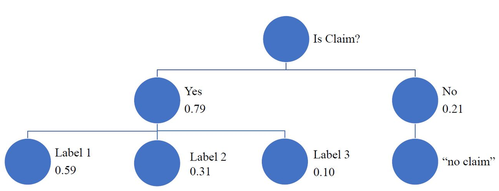

## Headline classification

In this post I demonstrate how to use the models developed in [MARDY](https://www.mardy-project.eu/) to identify and classify headlines from news reports (from the [German Tagesschau](https://www.tagesschau.de/) and the [British Guardian](https://www.theguardian.com/uk)) using R.[^1]

The goal is to a) identify political claims in the headers of news reports and b) label them according to the guidelines developed within MARDY.

### Accessing the data - Tagesschau

The first step is to download and prepare the data. In this example, I scrape the [first news page on the topic of migration](https://www.tagesschau.de/thema/migration/?pageIndex=1). I am interested in both the header and the additional short-text provided there.

```r
# load packages
library(rvest)
library(dplyr)

# scrape data
scrape_ts_ticker <- function(page){
          Sys.sleep(5)
          url <- paste0("https://www.tagesschau.de/thema/migration/?pageIndex=", page)
          page <- read_html(url)
          header <- page %>% html_nodes(".teaser__headline") %>% html_text(trim = T)
          date <- page %>% html_nodes(".teaser__date") %>% html_text(trim = T)
          shorttext <- page %>% html_nodes(".teaser__shorttext") %>% html_text(trim = T)
          df <- data.frame(header = gsub("\\s?\\+\\s?", "", header),
                           date = gsub("\\s.*", "", date),
                           shorttext = trimws(gsub("Von\\s+[A-Z].*mehr|\\n\\s+mehr", "", shorttext)))
          return(df)
}
ts_migr <- purrr::map_df(.x = 1, .f = scrape_ts_ticker)
saveRDS(ts_migr, "ts_migr.rds")
```

Let’s take a look at a sample of the data:

| date | header | shorttext |
| --- | --- | --- |
| 30.04.2023 | Franziskus wirbt in Ungarn für “offene Türen” | Papst Franziskus hat bei einer Freiluftmesse in Budapest für Toleranz und die Aufnahme von Migranten geworben. Damit distanzierte er sich von der Politik des ungarischen Ministerpräsidenten Orban - de… |
| 27.04.2023 | Unterhaus beschließt Gesetz gegen illegale Migration | Großbritannien will Migranten abschrecken: Wer illegal über den Ärmelkanal kommt, muss mit Internierung, einer Abschiebung nach Ruanda und einer lebenslangen Einreisesperre rechnen. Das Unterhaus besc… |
| 26.04.2023 | Hunderte Migranten erreichen Lampedusa | Noch immer wagen viele Menschen die gefährliche Flucht über das Mittelmeer. Allein seit Mitternacht kamen Hunderte Migranten auf der italienischen Insel Lampedusa an. Rettungskräfte fanden auch zwei L… |

In total the first page contains the headlines of 21 reports.

### Accessing the data - Guardian

After downloading the German data, I turn to the Guardian. Luckily, the Guardian provides an [API](https://open-platform.theguardian.com/) to access and filter their data base (Note: API key needed).

```r
library(glue)
library(httr)
tag <- "migration OR refugee"
page_size = 21
api_key <- "YOUR API KEY"
date <- "from-date=2023-01-01"
url <- glue('https://content.guardianapis.com/search?q={tag}&{date}&api-key={api_key}&page-size={page_size}&show-fields=headline,trailText')


get_guardian <- function(page){
          request <- GET(URLencode(glue("{url}&page={page}")))
          response <- content(request)$response$results
          guardian_migr <- purrr::map_chr(response, ~.x$fields$headline)
          guardian_migr_short <- purrr::map_chr(response, ~.x$fields$trailText)
          guardian_migr_date <- purrr::map_chr(response, ~.x$webPublicationDate)
          data.frame(date = guardian_migr_date, header = guardian_migr, shorttext = guardian_migr_short)
}

guardian <- purrr::map_df(1, get_guardian)
saveRDS(guardian, "guardian-world-migration-sample.rds")
```

Again, let’s take a look at a sample of the data ($N$ = 21):

| date | header | shorttext |
| --- | --- | --- |
| 2023-03-29T20:26:37Z | Illegal migration bill could topple world refugee system, lawmakers told | UN refugee agency representative warns that legislation could have ‘domino effect’ on other countries |
| 2023-03-07T20:10:09Z | UN refugee agency ‘profoundly concerned’ by UK’s illegal migration bill saying it amounts to an asylum ban – as it happened | UNHCR says bill extinguishes the right to seek refugee protection in the UK for those who arrive irregularly |
| 2023-03-07T18:01:12Z | ‘A revenge plan’: refugees and Dover residents react to illegal migration bill | Home secretary’s latest plan to curb small boats crossings across the Channel has been met with scepticism |

## Classification

Now that I have the data I want to classify, I start by setting up the `claimIdent`[^2] package that contains the necessary files needed for classification.

```r
library(claimIdent) # Unpublished at the time of publication of this post
configure()
```

```
Initializing - this may take a while...
```

This command needs to be run once a session and sets up the python environment, libraries, and code.[^3]. Afterwards the sentences can be classified as follows:

**Single-label classification German**

Classify the short-text provided and assign one label.

```r
library(purrr)
ts_res <- map_df(ts_migr$shorttext,
                 ~classify(.x, hits= 1, threshold = .9),
                 .id = "sentence"
                 )
knitr::kable(ts_res[1:3,])
```

| sentence | cat | cat_sim | label | claim_prob | query |
| --- | --- | --- | --- | --- | --- |
| 1 | 715 | 0.49 | open society | 0.873 | Papst Franziskus hat bei einer Freiluftmesse in Budapest für Toleranz und die Aufnahme von Migranten geworben. Damit distanzierte er sich von der Politik des ungarischen Ministerpräsidenten Orban - de… |
| 2 | 104 | 0.56 | isolation/immigration stop | 0.965 | Großbritannien will Migranten abschrecken: Wer illegal über den Ärmelkanal kommt, muss mit Internierung, einer Abschiebung nach Ruanda und einer lebenslangen Einreisesperre rechnen. Das Unterhaus besc… |
| 3 | NaN | 0.00 | no_claim | 0.000 | Noch immer wagen viele Menschen die gefährliche Flucht über das Mittelmeer. Allein seit Mitternacht kamen Hunderte Migranten auf der italienischen Insel Lampedusa an. Rettungskräfte fanden auch zwei L… |

**Multi-label classification German**

Classify the short-text provided and assign 5 labels.

```r
library(purrr)
library(tidyr)
ts_res_mult <- map_df(ts_migr$shorttext,
                 ~classify(.x, hits= 5, threshold = .9),
                 .id = "sentence"
                 )
ts_res_wide <- ts_res_mult %>%
          nest(data = c(cat, cat_sim, label)) %>%
          unnest_wider(data)
knitr::kable(ts_res_wide[1:3,])
```

| sentence | claim_prob | query | cat | cat_sim | label |
| --- | --- | --- | --- | --- | --- |
| 1 | 0.873 | Papst Franziskus hat bei einer Freiluftmesse in Budapest für Toleranz und die Aufnahme von Migranten geworben. Damit distanzierte er sich von der Politik des ungarischen Ministerpräsidenten Orban - de… | 715, 104, 712, 799, 706 | 0.49, 0.49, 0.44, 0.44, 0.43 | open society , isolation/immigration stop , public debate , General , Recognition of fundamental rights |
| 2 | 0.965 | Großbritannien will Migranten abschrecken: Wer illegal über den Ärmelkanal kommt, muss mit Internierung, einer Abschiebung nach Ruanda und einer lebenslangen Einreisesperre rechnen. Das Unterhaus besc… | 104, 207, 211, 408, 209 | 0.56, 0.54, 0.52, 0.49, 0.48 | isolation/immigration stop, deportations , right of abode , deprivation of liberty , residence obligation |
| 3 | 0.000 | Noch immer wagen viele Menschen die gefährliche Flucht über das Mittelmeer. Allein seit Mitternacht kamen Hunderte Migranten auf der italienischen Insel Lampedusa an. Rettungskräfte fanden auch zwei L… | NaN | 0 | no_claim |

**Single-label classification English**

Classify the headline provided and assign one label.

```r
library(purrr)
guardian_res <- map_df(guardian$header,
                 ~classify(.x, hits= 1, threshold = .9),
                 .id = "sentence"
                 )
knitr::kable(guardian_res[1:3,])
```

| sentence | cat | cat_sim | label | claim_prob | query |
| --- | --- | --- | --- | --- | --- |
| 1 | 108 | 0.49 | immigration law | 0.144 | Illegal migration bill could topple world refugee system, lawmakers told |
| 2 | 104 | 0.53 | isolation/immigration stop | 0.350 | UN refugee agency ‘profoundly concerned’ by UK’s illegal migration bill saying it amounts to an asylum ban – as it happened |
| 3 | 108 | 0.68 | immigration law | 0.720 | ‘A revenge plan’: refugees and Dover residents react to illegal migration bill |

**Multi-label classification English**

Classify the headline provided and assign five labels.

```r
library(purrr)
library(tidyr)
guardian_res_mult <- map_df(guardian$header,
                 ~classify(.x, hits= 5, threshold = .9),
                 .id = "sentence"
                 )
guardian_res_wide <- guardian_res_mult %>%
          nest(data = c(cat, cat_sim, label)) %>%
          unnest_wider(data)
knitr::kable(guardian_res_wide[1:3,])
```

| sentence | claim_prob | query | cat | cat_sim | label |
| --- | --- | --- | --- | --- | --- |
| 1 | 0.144 | Illegal migration bill could topple world refugee system, lawmakers told | 108, 509, 101, 114, 104 | 0.49, 0.37, 0.36, 0.36, 0.36 | immigration law , Dublin regulation , controlled migration , (Canadian) points system , isolation/immigration stop |
| 2 | 0.350 | UN refugee agency ‘profoundly concerned’ by UK’s illegal migration bill saying it amounts to an asylum ban – as it happened | 104, 207, 406, 509, 101 | 0.53, 0.49, 0.48, 0.44, 0.37 | isolation/immigration stop, deportations , ban mile , Dublin regulation , controlled migration |
| 3 | 0.720 | ‘A revenge plan’: refugees and Dover residents react to illegal migration bill | 108, 114, 104, 101, 509 | 0.68, 0.45, 0.44, 0.43, 0.42 | immigration law , (Canadian) points system , isolation/immigration stop, controlled migration , Dublin regulation |

- `sentence`: index of the queried sentence
- `cat`: assigned code-category from the codebook
- `cat_sim`: similarity of the queried sentence to the median-embedding of the assigned code-category
- `label`: corresponding label to the code-category
- `claim_prob`: probability of query containing a claim
- `query`: the queried sentence

## Conclusion

The results are not perfect but provide a good first impression from which the annotation can proceed semi-automatically.

## References

The data sets used to train the models are part of the following publications:

> Lapesa, G., Blessing, A., Blokker, N., Dayanik, E., Haunss, S., Kuhn, J., & Padó, S. (2020). DEbateNet-mig15: Tracing the 2015 immigration debate in Germany over time. Proceedings of LREC, 919–927. https://www.aclweb.org/anthology/2020.lrec-1.115

> Blokker, N., Blessing, A., Dayanik, E., Kuhn, J., Padó, S., & Lapesa, G. (2023). Between welcome culture and border fence. A dataset on the European refugee crisis in German newspaper reports. Language Resources and Evaluation, 121 - 153. https://link.springer.com/article/10.1007/s10579-023-09641-8

## Footnotes

[^1]: Making use of the `reticulate` package to run python code from R
[^2]: Unpublished at the time of publication of this post; check https://github.com/nicoblokker/claim-classification for updates.
[^3]: Python and the required libraries need to be installed properly first, see Github repository.